```python
import numpy as np
import numpy.linalg as la
import matplotlib
import matplotlib.pyplot as plt
from skimage.measure import ransac

%matplotlib notebook
```

```python
class LeastSquareLine:

    def __init__(self):
        self.a = 0.0
        self.b = 0.0

    def estimate(self, points2D):
        B = points2D[:,1]
        A = np.copy(points2D)
        A[:,1] = 1.0

        # SVD (singular value decomposition) for (Nx2) matrix A = U*diag(S)*V  where N is the number of points
        # matrix V is 2x2, matrix U is Nx2, and S is a vector (Nx1 array) of eigen values for A
        u,s,v = la.svd(A, full_matrices=False)

        #least square line fit = v' * 1/s * u' * B
        ls_line = np.transpose(v).dot(np.diag(1.0/s)).dot(np.transpose(u).dot(B))
        self.a = ls_line[0]
        self.b = ls_line[1]
        return True

    def predict(self, x): return (self.a * x) + self.b

    def predict_y(self, x): return (self.a * x) + self.b

    def residuals(self, points2D):
        return points2D[:,1] - self.predict(points2D[:,0])

    def line_par(self):
        return self.a, self.b
```

# RANSAC for robust line fitting (single model case)

### Step 1: generating noisy data with outliers

```
(400, 2)
```

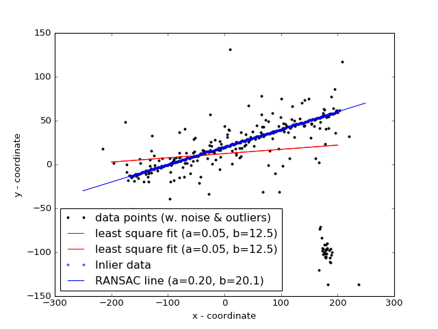

```python
np.random.seed(seed=1)

# parameters for "true" line y = a*x + b
a, b = 0.2, 20.0

# x-range of points [x1,x2]
x_start, x_end = -200.0, 200.0

# generate the "true" line points
x = np.arange(x_start,x_end)
y = a * x + b
data = np.column_stack([x, y])    # staking data points into (Nx2) array
# add faulty data (i.e. outliers)
faulty = np.array(30 * [(180., -100)])  # (30x2) array containing 30 rows [180,-100]  (points)
faulty += 5 * np.random.normal(size=faulty.shape)  # adding Gaussian noise to these points
data[:faulty.shape[0]] = faulty   # replacing the first 30 points in data with faulty (outliers)
print data.shape
# add gaussian noise to coordinates
noise = np.random.normal(size=data.shape) # generating Gaussian noise (variance 1) for each data point (rows in 'data')
data += 0.5 * noise
data[::2] += 5 * noise[::2]  # every second point adds noise with variance 5
data[::4] += 20 * noise[::4] # every fourth point adds noise with variance 20

fig, ax = plt.subplots()
ax.plot(data[:,0], data[:,1], '.k', label='data points (w. noise & outliers)')
ax.set_xlabel('x - coordinate')
ax.set_ylabel('y - coordinate')
ax.legend(loc='lower left')
plt.show()
```

### Step 2: least-square line fitting

```python
LSline = LeastSquareLine() # uses class implemented at the top of this notebook
print LSline.estimate(data)
a_ls, b_ls = LSline.line_par()

# visualizing estimated line
ends = np.array([x_start,x_end])
ax.plot(ends, LSline.predict(ends), '-r', label='least square fit (a={:4.2f}, b={:4.1f})'.format(a_ls,b_ls))
ax.legend(loc='lower left')
plt.show()
```

```
True
```

### Step 3: robust line fitting (RANSAC)

```python
# robustly fit line only using inlier data with RANSAC algorithm
model_robust, inliers = ransac(data, LeastSquareLine, min_samples=2, residual_threshold=1, max_trials=1000)
a_rs, b_rs = model_robust.line_par()

# generate coordinates of estimated models
line_x = np.arange(-250, 250)
line_y_robust = model_robust.predict_y(line_x)

#fig, ax = plt.subplots()
ax.plot(data[inliers, 0], data[inliers, 1], '.b', alpha=0.6, label='Inlier data')
ax.plot(line_x, line_y_robust, '-b', label='RANSAC line (a={:4.2f}, b={:4.1f})'.format(a_rs,b_rs))
ax.legend(loc='lower left')
plt.show()
```

# Sequential RANSAC for robust multi-line fitting

### Step 1: generating noisy data with outliers

```
(800, 2)
```

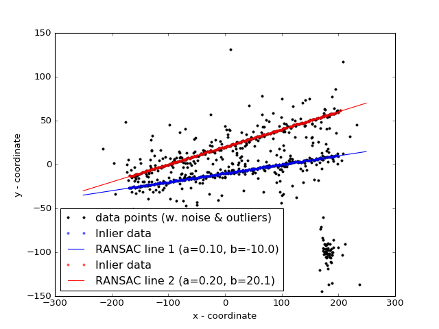

```python
# parameters for "true" lines y = a*x + b
a2, b2 = 0.1, -10.0

# generate the "true" line points
y2 = a2 * x + b2
data2 = np.column_stack([x, y2])    # staking data points into (Nx2) array

# add faulty data (i.e. outliers)
faulty = np.array(30 * [(180., -100)])  # (30x2) array containing 30 rows [180,-100]  (points)
faulty += 5 * np.random.normal(size=faulty.shape)  # adding Gaussian noise to these points
data2[:faulty.shape[0]] = faulty   # replacing the first 30 points in data2 with faulty (outliers)

# add gaussian noise to coordinates
noise = np.random.normal(size=data.shape) # generating Gaussian noise (variance 1) for each data point (rows in 'data')
data2+= 0.5 * noise
data2[::2] += 5 * noise[::2]  # every second point adds noise with variance 5
data2[::4] += 20 * noise[::4] # every fourth point adds noise with variance 20

data = np.concatenate((data,data2)) # combining with previous data
print data.shape

fig, ax = plt.subplots()
ax.plot(data[:,0], data[:,1], '.k', label='data points (w. noise & outliers)')
ax.set_xlabel('x - coordinate')
ax.set_ylabel('y - coordinate')
ax.legend(loc='lower left')
plt.show()
```

### Step 2: find a line using RANSAC

```python
model_robust1, inliers = ransac(data, LeastSquareLine, min_samples=2, residual_threshold=1, max_trials=1000)
outliers = (inliers == False)
a1_rs, b1_rs = model_robust1.line_par()

# generate coordinates of estimated models
line_x = np.arange(-250, 250)
line_y_robust = model_robust1.predict_y(line_x)

ax.plot(data[inliers, 0], data[inliers, 1], '.b', alpha=0.6, label='Inlier data')
ax.plot(line_x, line_y_robust, '-b', label='RANSAC line 1 (a={:4.2f}, b={:4.1f})'.format(a1_rs,b1_rs))
ax.legend(loc='lower left')
plt.show()
```

### Step 3: Fit another line after removing inliers for the first line (detected above)

```python
data_remaining = data[outliers]
model_robust2, inliers = ransac(data_remaining, LeastSquareLine, min_samples=2, residual_threshold=1, max_trials=1000)
a2_rs, b2_rs = model_robust2.line_par()

# generate coordinates of estimated models
line_x = np.arange(-250, 250)
line_y_robust = model_robust2.predict_y(line_x)

ax.plot(data_remaining[inliers, 0], data_remaining[inliers, 1], '.r', alpha=0.6, label='Inlier data')
ax.plot(line_x, line_y_robust, '-r', label='RANSAC line 2 (a={:4.2f}, b={:4.1f})'.format(a2_rs,b2_rs))
ax.legend(loc='lower left')
plt.show()
```

# Multi-line fitting for (Canny) edges

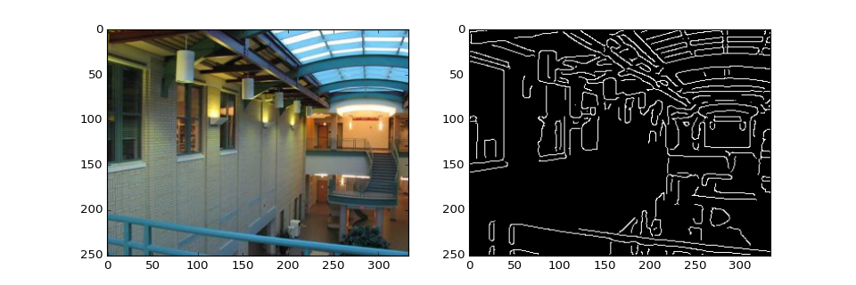

```python
import matplotlib.image as image
from skimage import feature
from skimage.color import rgb2gray

im = image.imread("images/CMU_left.jpg")
imgray = rgb2gray(im)
can = feature.canny(imgray, 2.0)

plt.figure(3,figsize = (12, 4))
plt.subplot(121)
plt.imshow(im)
plt.subplot(122)
plt.imshow(can,cmap="gray")
plt.show()
```

# Assignment: use sequential-RANSAC to find $K$ lines

```python
K = 10

def K_lines(k,img,minimum,threshold,trials):
    #read images, get the canny edges image
    imgray = rgb2gray(img)
    canny = feature.canny(imgray, 1.0)
    dataPoints = np.transpose(np.where(canny==True))
    #set the plots
    fig3, ax2 = plt.subplots()
    ax2.plot(dataPoints[:,0], dataPoints[:,1], '.k', label='data points (w. noise & outliers)')
    ax2.set_xlabel('x - coordinate')
    ax2.set_ylabel('y - coordinate')

#     print dataPoints[0]
#     print canny.shape
#     plt.imshow(canny,cmap="gray",origin="lower")

    model_robust_k,inliners_k = ransac(dataPoints,LeastSquareLine, min_samples = minimum , residual_threshold=threshold, max_trials =trials)
    outliers_k = (inliners_k == False)
    al_rs, bl_rs = model_robust_k.line_par()

    line_x = np.arange(0,im.shape[1])
    line_y_robust = model_robust_k.predict_y(line_x)
    ax2.plot(dataPoints[inliners_k, 0], dataPoints[inliners_k, 1], '.r', alpha=0.6, label='Inlier data')
    ax2.plot(line_x, line_y_robust, '-r')

    colors = ['-g', '-b', '-k', '-w', '-m', '-c', '-r', '-y']
    colors2 = ['.g', '.b', '.k', '.w', '.m', '.c', '.r', '.y']
    size = len(colors)
    for i in np.arange(k):
        data_remaining = dataPoints[outliers_k]
        dataPoints =  data_remaining
#     dataPoints =  data_remaining
        model_robust3, inliers = ransac(data_remaining, LeastSquareLine, min_samples= minimum, residual_threshold=threshold, max_trials=trials)
        outliers_k = (inliers == False)
        a3_rs, b3_rs = model_robust2.line_par()

        line_x = np.arange(0,canny.shape[0])
        line_y_robust = model_robust3.predict_y(line_x)

        ax2.plot(data_remaining[inliers, 0], data_remaining[inliers, 1], colors2[i%size], alpha=0.6, label='Inlier data')
#     ax2.plot(line_x, line_y_robust, '-r', label='RANSAC line 2 (a={:4.2f}, b={:4.1f})'.format(a3_rs,b3_rs))
        ax2.plot(line_x, line_y_robust, colors[i%size])


    plt.show()


#image and data

# K_lines(5,im,300,10,1000)
```

## Different values of K

K = 10

k = 20

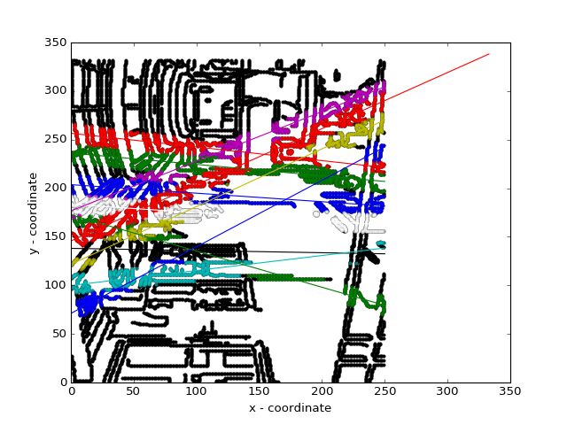

```python
K_lines(10,im,50,10,1000)
```

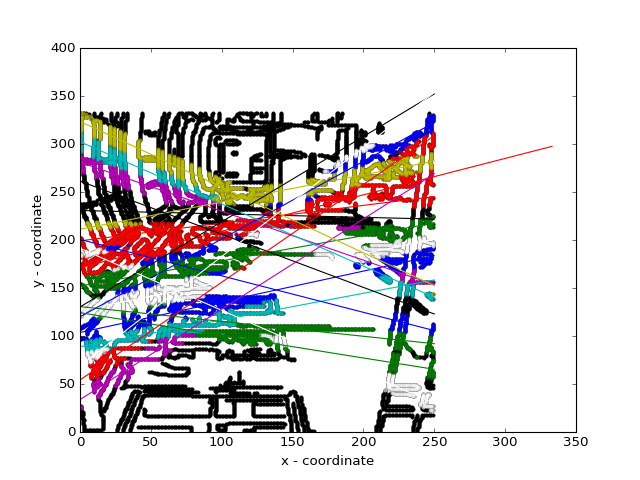

```python
K_lines(20,im,50,10,1000)
```

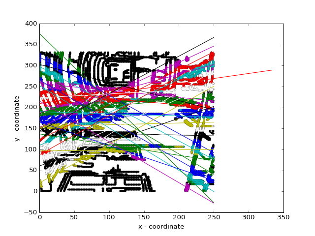

```python
K_lines(30,im,50,10,1000)
```

## Different Threshold

set k = 20

1. 5
2. 15
3. 30

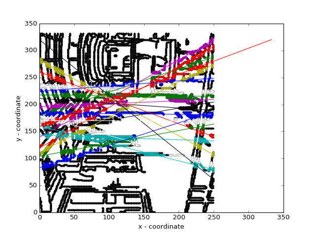

```python
K_lines(20,im,50,5,1000)
```

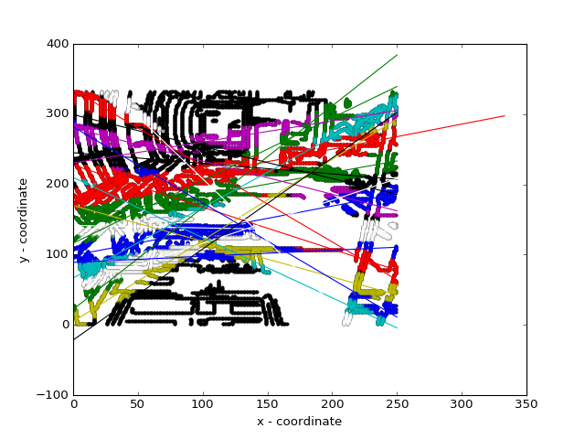

```python
K_lines(20,im,50,15,1000)
```

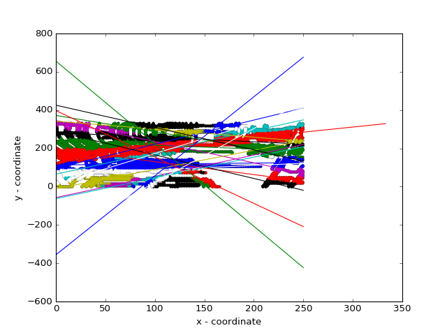

```python
K_lines(20,im,50,30,1000)
```

## Different max_trials

1. 500
2. 1500
3. 3000

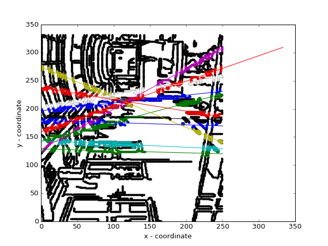

```python
K_lines(10,im,50,5,500)
```

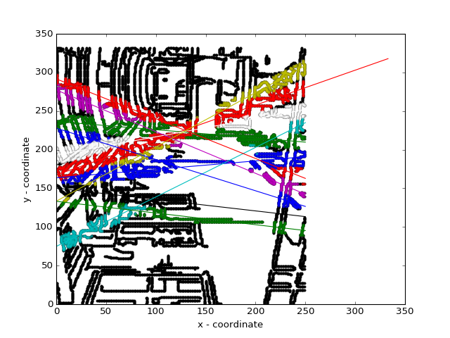

```python
K_lines(10,im,50,10,1500)
```

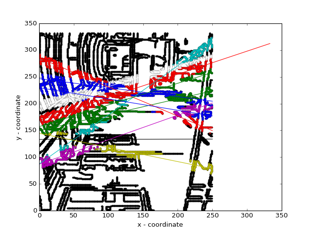

```python
K_lines(10,im,50,10,3000)
```

## Discussion

From trying different parameters, we can see a certain things.

One obvious results is that Sequential RANSAC performs well as the number of trials increase, it allows the algorithm to iterates through more possibilities and hence find a better results. But the running speed also decrease as the number of trials increase.

The other thing we may find is that, the number of threshold will have a significant impact on the results as well. Ideally if we want to match the edges of images well, the threshold will most likely to be small a number, however, it depends how the picture is lay as well as the resolution of it. So it’s something that we should find a better way to decide.

As for the minimum number of points for line, that’s also important as well.

## Hough Transform

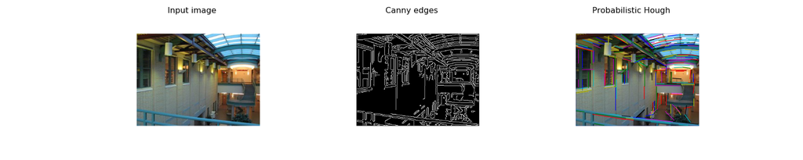

```python
from skimage.transform import (hough_line, hough_line_peaks,
                               probabilistic_hough_line)
from skimage.feature import canny
import matplotlib.image as image

# Line finding, using the Probabilistic Hough Transform

im = image.imread("images/CMU_left.jpg")
imgray = rgb2gray(im)
edges = canny(imgray, 1.0)
lines = probabilistic_hough_line(edges, threshold=10, line_length=20
,
                                 line_gap=3)

fig, (ax1, ax2, ax3) = plt.subplots(1, 3, figsize=(20,4), sharex=True, sharey=True)

ax1.imshow(im)
ax1.set_title('Input image')
ax1.set_axis_off()
ax1.set_adjustable('box-forced')

ax2.imshow(edges, cmap=plt.cm.gray)
ax2.set_title('Canny edges')
ax2.set_axis_off()
ax2.set_adjustable('box-forced')

ax3.imshow(edges * 0)
ax3.imshow(im)

for line in lines:
    p0, p1 = line
    ax3.plot((p0[0], p1[0]), (p0[1], p1[1]))

ax3.set_title('Probabilistic Hough')
ax3.set_axis_off()
ax3.set_adjustable('box-forced')
plt.show()
```